# Data analytics for economists: Assignment I

Dirga Imam Gozali Sumantri, Muhammad Yudha Pratama, Nefertari Pramudhita, Nurwahid Najmuddin Ahmad

We will go through five steps processes: (1) Import the data, (2) Preprocessing the data, (3) Exploratory Data Analysis, (4) Model Selection, (5) Applying the Model and Reporting the prediction

# 1 Import the Data

```r
# We need to load all of the libraries used for this data analysis.

library(data.table)
library(ggplot2)
library(caret)
library(SuperLearner)
library(glmnet)
library(randomForest)
library(xgboost)
library(rpart)
train <- fread("https://www.dropbox.com/s/5rr2ysw6tjcnbpj/train.csv?dl=1")
test <- fread("https://www.dropbox.com/s/395thqjfxf7k4wi/test.csv?dl=1")
```

# 2 Preprocessing

## 2.1 Changing variable characters to factor

Because some variables are character, we change them to factor.

```r
get_factor <- function(x){
  if (class(x) == "character"){
    factor(x)
  } else {
    x
  }
}
train[, names(train) := lapply(.SD, get_factor)]
test[, names(test) := lapply(.SD, get_factor)]
str(train)
```

```
## Classes 'data.table' and 'data.frame':   9626 obs. of  51 variables:
##  $ player_ID                 : int  2463 2511 12483 2986 1842 13556 13326 11638 6746 9819 ...
##  $ age                       : int  23 24 21 21 29 28 21 33 32 31 ...
##  $ height_cm                 : int  193 177 171 182 187 168 175 181 183 175 ...
##  $ weight_kg                 : int  84 72 68 73 88 66 70 72 79 68 ...
##  $ wage_eur                  : int  15000 13000 4000 21000 23000 1000 1000 2000 1000 2000 ...
##  $ preferred_foot            : Factor w/ 2 levels "Left","Right": 2 2 2 1 2 2 2 2 2 2 ...
##  $ international_reputation  : int  1 1 1 1 1 1 1 1 1 1 ...
##  $ weak_foot                 : int  3 5 3 3 3 3 2 3 2 2 ...
##  $ skill_moves               : int  2 4 2 3 3 3 2 2 3 2 ...
##  $ work_rate                 : Factor w/ 9 levels "High/High","High/Low",..: 6 3 9 9 8 3 3 9 8 3 ...
##  $ team_position             : Factor w/ 28 levels "CAM","CB","CDM",..: 8 28 21 28 13 28 17 28 27 23 ...
##  $ pace                      : int  56 83 70 66 56 77 64 37 67 82 ...
##  $ shooting                  : int  25 69 55 58 75 49 26 33 67 52 ...
##  $ passing                   : int  45 68 57 70 61 53 50 44 55 61 ...
```

[output cut: 38 more lines]

## 2.2 Data Split

To avoid confusion from the raw dataset of train and public test set, we named our training data “Intrain”, and testing data “Intest” (public test set)

```r
set.seed(1212)
train_id <- sample(1:nrow(train), 0.8*nrow(train))

Intrain <- train[train_id, ]
Intest <- train[-train_id, ]
Y_Intest <- Intest$wage_eur
Y_Intrain <- Intrain$wage_eur

X_Intrain <- model.matrix(wage_eur ~ . , Intrain)[, -1]
X_Intest <- model.matrix(wage_eur ~ . , Intest)[, -1]
```

# 3 Exploratory Data Analysis

## 3.1 Examining Data Distributions

```r
sum(is.na(c(train, test))) #checking whether there are missing observations
```

```
## [1] 0
```

```r
str(train)
```

```
## Classes 'data.table' and 'data.frame':   9626 obs. of  51 variables:
##  $ player_ID                 : int  2463 2511 12483 2986 1842 13556 13326 11638 6746 9819 ...
##  $ age                       : int  23 24 21 21 29 28 21 33 32 31 ...
##  $ height_cm                 : int  193 177 171 182 187 168 175 181 183 175 ...
##  $ weight_kg                 : int  84 72 68 73 88 66 70 72 79 68 ...
##  $ wage_eur                  : int  15000 13000 4000 21000 23000 1000 1000 2000 1000 2000 ...
##  $ preferred_foot            : Factor w/ 2 levels "Left","Right": 2 2 2 1 2 2 2 2 2 2 ...
##  $ international_reputation  : int  1 1 1 1 1 1 1 1 1 1 ...
##  $ weak_foot                 : int  3 5 3 3 3 3 2 3 2 2 ...
##  $ skill_moves               : int  2 4 2 3 3 3 2 2 3 2 ...
##  $ work_rate                 : Factor w/ 9 levels "High/High","High/Low",..: 6 3 9 9 8 3 3 9 8 3 ...
##  $ team_position             : Factor w/ 28 levels "CAM","CB","CDM",..: 8 28 21 28 13 28 17 28 27 23 ...
##  $ pace                      : int  56 83 70 66 56 77 64 37 67 82 ...
##  $ shooting                  : int  25 69 55 58 75 49 26 33 67 52 ...
##  $ passing                   : int  45 68 57 70 61 53 50 44 55 61 ...
```

[output cut: 38 more lines]

We want to examine the distribution of the dependent variable, the wages of each football player.

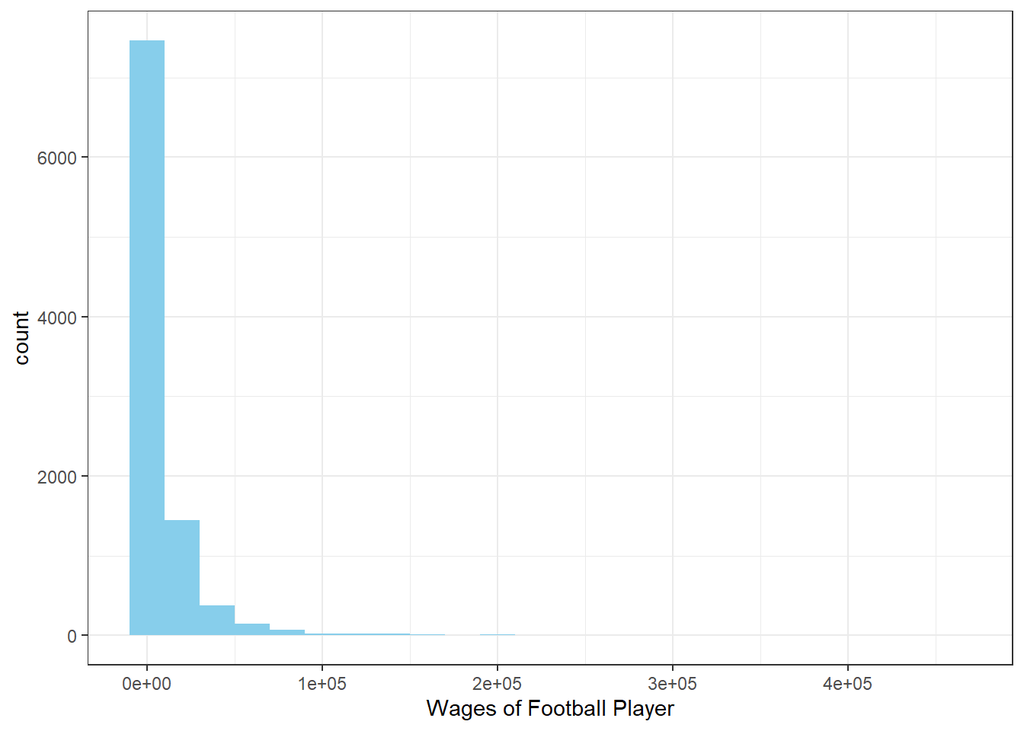

```r
ggplot(data = train, aes(x = wage_eur))+
  geom_histogram(binwidth = 20000, fill="skyblue")+
  theme(panel.grid.major = element_blank())+
  theme_bw()+
  xlab("Wages of Football Player")
```

Here, we could see that the wages is highly right skewed. Next, we explore some possible correlations between Wages, age, grouped by international reputations.

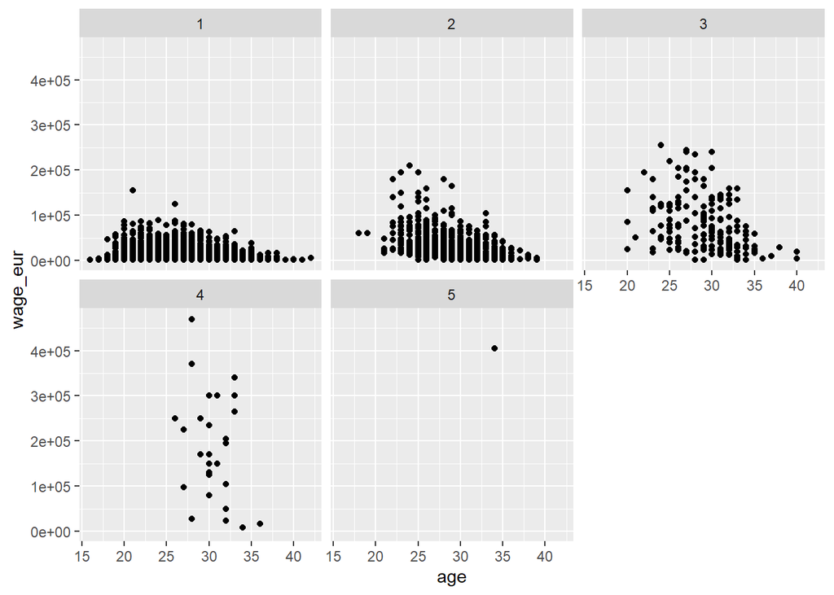

```r
ggplot(data = train) +
  geom_point(mapping = aes(x = age, y = wage_eur)) +
  facet_wrap(~ international_reputation)
```

Here, we could see that different groups of international reputation have quite different distribution of age and wages.

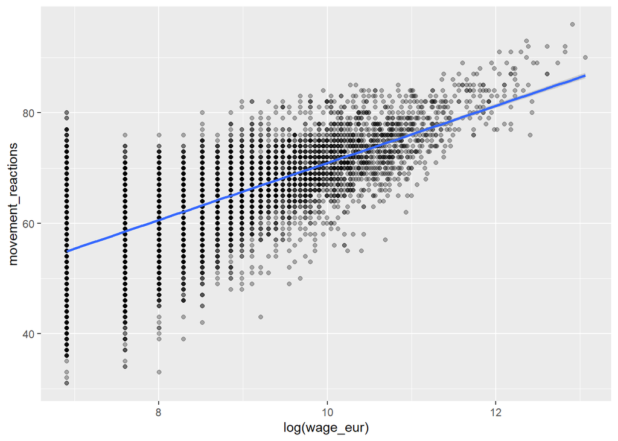

```r
ggplot(data = train, aes(x = log(wage_eur), y=movement_reactions))+
  geom_point(alpha=0.3, fill="skyblue")+
  geom_smooth(method = lm)
```

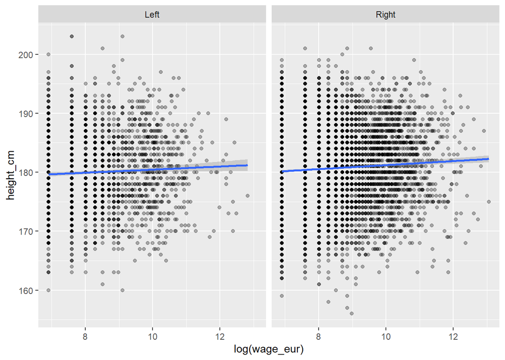

```r
ggplot(data = train, aes(x = log(wage_eur), y=height_cm))+
  geom_point(alpha=0.3, fill="skyblue")+
  geom_smooth(method = lm)+
  facet_wrap(~preferred_foot)
```

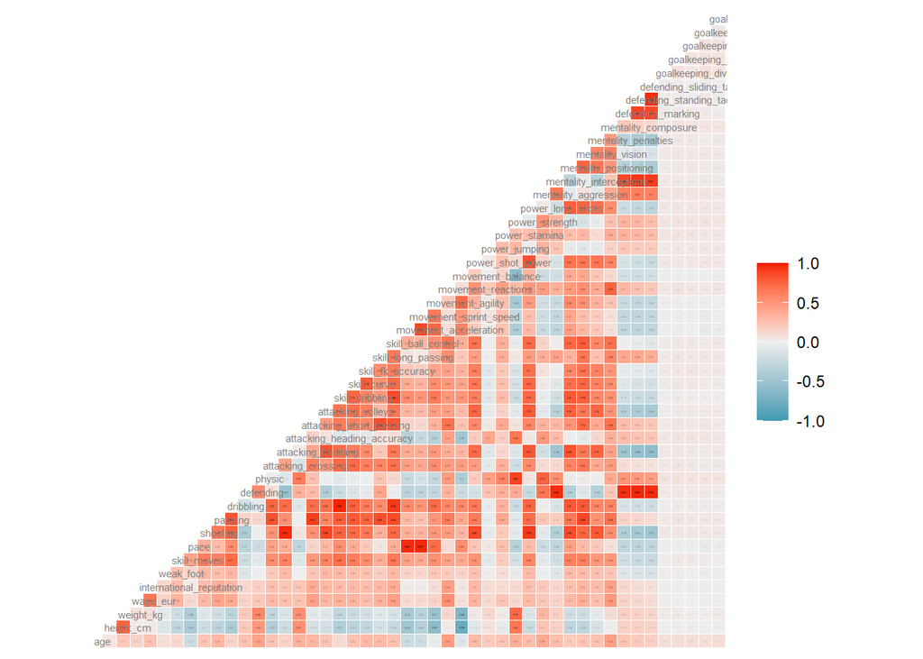

```r
library(GGally)
ggcorr(train[, -"player_ID"], method = c("everything", "pearson"), hjust = 0.1, size = 2, color = "grey50", label = TRUE, label_size = 0.5, label_round = 2, label_alpha = TRUE, )
```

## Summary Statistics We presents here some summary statistics only for the second up to the tenth variable.

```r
summary(train[, 2:10])
```

```
##       age          height_cm       weight_kg         wage_eur
##  Min.   :16.00   Min.   :156.0   Min.   : 52.00   Min.   :  1000
##  1st Qu.:21.00   1st Qu.:176.0   1st Qu.: 70.00   1st Qu.:  1000
##  Median :25.00   Median :180.0   Median : 74.00   Median :  3000
##  Mean   :25.09   Mean   :180.5   Mean   : 74.44   Mean   : 10174
##  3rd Qu.:28.00   3rd Qu.:185.0   3rd Qu.: 79.00   3rd Qu.:  9000
##  Max.   :42.00   Max.   :203.0   Max.   :110.00   Max.   :470000
##
##  preferred_foot international_reputation   weak_foot      skill_moves
##  Left :2424     Min.   :1.000            Min.   :1.000   Min.   :2.000
##  Right:7202     1st Qu.:1.000            1st Qu.:3.000   1st Qu.:2.000
##                 Median :1.000            Median :3.000   Median :2.000
##                 Mean   :1.107            Mean   :2.997   Mean   :2.541
##                 3rd Qu.:1.000            3rd Qu.:3.000   3rd Qu.:3.000
##                 Max.   :5.000            Max.   :5.000   Max.   :5.000
##
##          work_rate
##  Medium/Medium:4624
##  High/Medium  :1923
##  Medium/High  : 999
##  High/High    : 597
##  Medium/Low   : 531
##  High/Low     : 404
##  (Other)      : 548
```